# Análise de valor minímo

Esta análise discorre sobre dados de vendas de personagens de um mmprg anunciados no site oficial do game que funciona de modo de leilão onde os próprios jogadores podem anunciar seus respectivos personagens para venda. Foi coletada uma amostra dos últimos 25.000 anúncios, feitos durante o período de 13/11/2020 a 32/12/2020. Não está sendo levado em consideração o status da venda (se foi vendido ou não), será analisada a expectativa do usuário que anuncia seu personagem, uma vez que é ele quem define o preço praticado.  
Neste estudo vamos analisar o preço minímo a ser pago por um personagem (57 Tibia coins), imaginando um cenário onde queira se gastar o minímo possível o que podemos obter com a quantia.

##### Glosário

Bid: valor do lance de leilão em Tibia coins (moeda interna do jogo)  
World: servidor que foi anunciado  
Vocation: classe de cada personagem  
Tibia coins: moeda do jogo

Podemos ver na tabela que o valor inicial mais baixo ofertado no leilão (57 Tibia coins) é também o mais presente, com 688 registros, representando 2,75% do total. Seguido de valores 500, 1000, 2000, 1500, que também podem representar uma preferência em valores redondos.

```r
data_tibia %>%
  mutate(valor_min=if_else(bid==57,1,0)) %>%
  count(bid) %>%
  group_by(bid) %>%
  summarise(Quantidade=n,Taxa=(n/25000)*100) %>%
  arrange(desc(Taxa)) %>%
  slice(1:5)
```

| bid | Quantidade | Taxa |
| --- | --- | --- |
| 57 | 688 | 2.752 |
| 500 | 524 | 2.096 |
| 1000 | 469 | 1.876 |
| 2000 | 448 | 1.792 |
| 1500 | 435 | 1.740 |

Já filtrado apenas valores minímos de leilão que são 57 Tc’s, qual vocação tem mais presença nos anúncios? Notadamente, vocações Paladin e Sorcerer têm mais aparições se comparada as demais. E rooker, por sua vez, é mais dificil de se encontra-los.

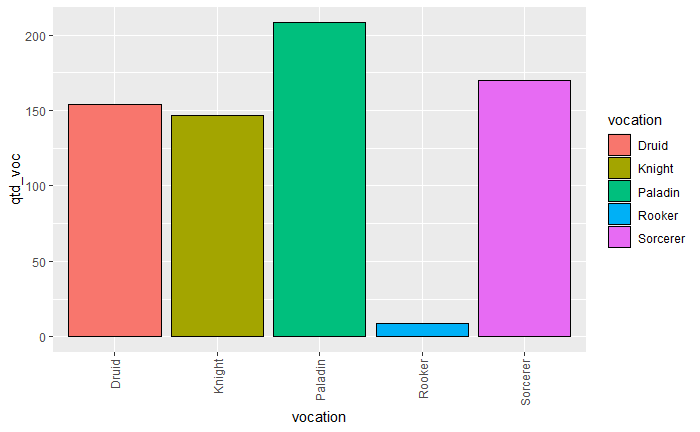

```r
data_tibia %>%
  filter(bid==57) %>%
  group_by(vocation) %>%
  summarise(qtd_voc=sum(n())) %>%
  ungroup() %>%
  ggplot(aes(x=vocation,y=qtd_voc,fill=vocation))+
  geom_bar(stat = "identity",color='black') +
    theme(axis.text.x=element_text(angle=90,hjust=1,vjust=0.5))
```

Os servidores (world) são hospedados foram classificados em South/North America e Europe, que são suas reais localizações. Com base nessa separação, é visível que a ordem de anúncios entre os continentes por venda de vocação não se altera muito. Também é possível notar que Rooker mesmo sendo uma pequena quantia, tem seu maior número de anúncios em servidores europeus.

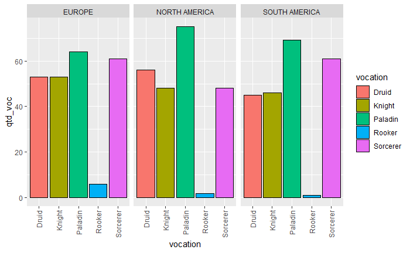

```r
data_tibia %>%
  filter(bid==57) %>%
   mutate(regiao= case_when(
    str_sub(world,-3)=='bra'~ 'SOUTH AMERICA',
    str_sub(world,-3)=='era'~ 'NORTH AMERICA',
    TRUE~'EUROPE'
  )) %>%
  group_by(vocation,regiao) %>%
  summarise(qtd_voc=sum(n())) %>%
  ggplot(aes(x=vocation,y=qtd_voc,fill=vocation))+
  geom_bar(stat = "identity",color='black') +
    theme(axis.text.x=element_text(angle=90,hjust=1,vjust=0.5))+
  facet_wrap(~regiao)
```

Os Paladinos têm mais anúncios, mas no boxplot pode-ser ver que os leveis são equilibrados não sofrendo com outliers. O sorcerer demonstra ser uma vocação monetariamente melhor, com apenas 57 Tibia coins pode-se encontrar com certa facilidade personagens de level 80 e também encontrar acima de level 110. O Druid, entretanto, pode ser uma aposta, por conter 6 outliers de leveis altos, sendo uma “barganha” para um lance de 57 Tc’s.

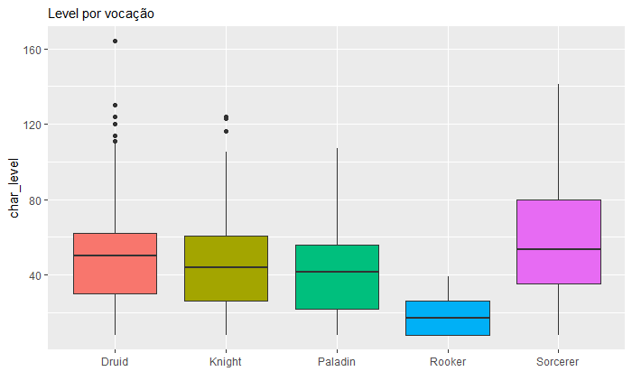

Olhando a densidade por vocação, confirma-se que Sorcerer tem um range maior de level, sendo o mais barato, e também que Rooker frequentemente são os mais caros

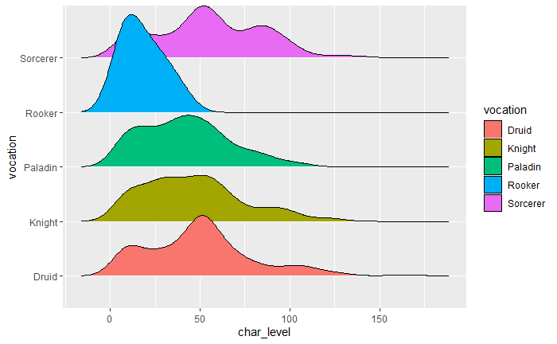

Visando agora a distribuição entre todos O histograma mostra que os personagens de level 8 e 50 têm um pico nos anúncios, e que a partir do level 100, esperadamente, as quantidades sofrem uma queda.

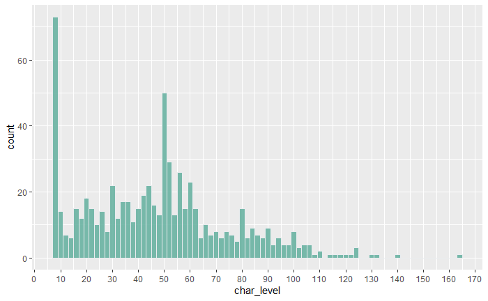